# SLR - In-Class - Lab Exercise (Day 1) - Solutions [v4.0 - 080121]

|  | Inclass - Lab (Day 1) |
| --- | --- |

### About the data set 1 (Life Expectancy data)

The dataset contains information about several health and economic factors that contribute to average life expectancy for different countries.  
Attribute information:

**Country:** Name of the country

**Status:** Whether the country is Developed or Developing

**Adult_Mortality:** Mortality rate for age group 15-60 out of every 1000 individuals of the population

**Infant_Deaths:** Number of infant deaths per 1000 population

**Hepatitis:** Hepatitis B (HepB) immunization coverage for 1 year olds (Percentage)

**Measles:** Number of reported cases for measles per 1000 from population

**BMI:** Average Body Mass Index for entire population

**Underfive_Deaths:** Number of deaths under 5 years of age per 1000 population

**Polio:** Polio (Pol3) immunization coverage for 1 year olds (Percentage)

**Diphtheria:** Diphtheria tetanus toxoid and pertussis (DTP3) immunization coverage for 1 year olds (Percentage)

**HIV:** Deaths per 1000 live births due to HIV/AIDS (0-4 years)

**GDP:** Gross Domestic Product per capita (in USD)

**Population:** Population of the country

**Malnourished10_19:** Prevalence of malnutrition among children and adolescents for Age 10 to 19 (Percentage)

**Malnourished5_9:** Prevalence of malnutrition among children for Age 5 to 9 (Percentage)

**Income_Index:** Human Development Index (HDI) in terms of national income per capita (index ranging from 0 to 1)

**Schooling:** Number of years of Schooling

**Life_Expectancy:** Life Expectancy in age for the country

## Table of Content

1. **Bivariate Regression**
2. **Multiple Linear Regression (MLR)**
3. **Inferences about slope**
4. **Model Evaluation**
5. **Assumptions of Linear Regression**
6. **Model Performance**

**Import the required libraries**

```python
# import 'Pandas'
import pandas as pd

# import 'Numpy'
import numpy as np

# import 'matplotlib.pyplot'
import matplotlib.pyplot as plt

# import 'Seaborn'
import seaborn as sns

# to suppress warnings
from warnings import filterwarnings
filterwarnings('ignore')

# display all columns of the dataframe
pd.options.display.max_columns = None

# display all rows of the dataframe
pd.options.display.max_rows = None

# to suppress the notation 'e'
pd.options.display.float_format = '{:.6f}'.format

# import various metrics from 'Scikit-learn' (sklearn)
from sklearn.model_selection import train_test_split

# 'Statsmodels' is used to build and analyze various statistical models
import statsmodels
import statsmodels.api as sm
import statsmodels.stats.api as sms
import statsmodels.formula.api as smf
from statsmodels.tools.eval_measures import rmse
from statsmodels.compat import lzip
from statsmodels.stats.outliers_influence import variance_inflation_factor
from statsmodels.stats.diagnostic import linear_rainbow
import statsmodels.tsa.api as smt
from statsmodels.graphics.gofplots import qqplot
from statsmodels.stats.stattools import durbin_watson

# 'SciPy' is used to perform scientific computations
from scipy import stats
from scipy.stats import shapiro

# 'metrics' from sklearn is used for evaluating the model performance
from sklearn.metrics import mean_absolute_error
from sklearn.metrics import mean_squared_error
```

#### Load the first dataset and check the first five observations

Load the csv file and set the first column as index

```python
# load the csv file
df_lifeExp = pd.read_csv('Life_Expectancy.csv', index_col=0)

# display the first two observations
df_lifeExp.head(2)
```

| Country | Status | Adult_Mortality | Infant_Deaths | Hepatitis | Measles | BMI | Underfive_Deaths | Polio | Diphtheria | HIV | GDP | Population | Malnourished10_19 | Malnourished5_9 | Income_Index | Schooling | Expected |
| --- | --- | --- | --- | --- | --- | --- | --- | --- | --- | --- | --- | --- | --- | --- | --- | --- | --- |
| Afghanistan | Developing | 263 | 62 | 65 | 1154 | 19.100000 | 83 | 6 | 65 | 0.100000 | 584.259210 | 33736494 | 17.200000 | 17.300000 | 0.479000 | 10.100000 | 65.000000 |
| Albania | Developing | 8 | 0 | 98 | 0 | 57.200000 | 1 | 98 | 98 | 0.100000 | 4575.763787 | 288914 | 1.200000 | 1.300000 | 0.761000 | 14.200000 | 77.500000 |

```python
# check data types of variables
df_lifeExp.dtypes
```

```
Status                 object
Adult_Mortality         int64
Infant_Deaths           int64
Hepatitis               int64
Measles                 int64
 BMI                  float64
Underfive_Deaths        int64
Polio                   int64
Diphtheria              int64
 HIV                  float64
GDP                   float64
Population              int64
Malnourished10_19     float64
Malnourished5_9       float64
Income_Index          float64
Schooling             float64
Expected              float64
dtype: object
```

### Let's begin with some hands-on practice exercises

## 1. Bivariate Regression

## We shall use the life expectancy dataset

|  | **1. How do we analyze the impact of adult mortality rate on average life expectancy of a country?** |
| --- | --- |

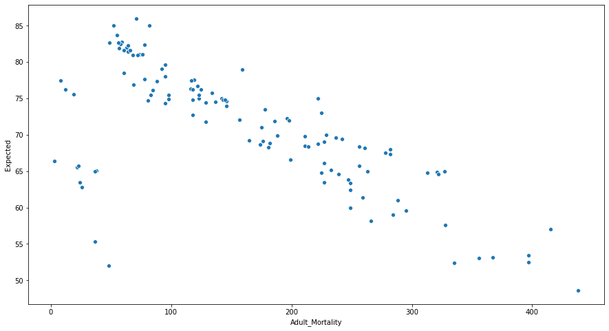

```python
# set dimensions for the plot figure
fig_dims = (15,8)
fig, ax = plt.subplots(figsize=fig_dims)

# plot a scatter plot to check the relationship
sns.scatterplot(df_lifeExp['Adult_Mortality'],df_lifeExp.Expected)

# display the plot
plt.show()
```

As we can see from the figure above, the adult mortality rate and average life expectancy of a country have a negative linear relationship between them. Hence bivariate regression can be used to capture and analyze the impact adult mortality has on life expectancy.

|  | **2. A regression model is built to check the impact of Human Development Index (Income) on the life expectancy of a nation. What is the expected error value?** |
| --- | --- |

```python
# selecting independent variables that describe immunization
X = df_lifeExp['Income_Index']

# 'sm.add_constant' adds the intercept to the model
X = sm.add_constant(X)

# set the dependent variable
y = df_lifeExp.Expected

# building a model with an intercept
# fit() is used to fit the OLS model
SLR_model = sm.OLS(y,X).fit()

# capture predicted values
predictions = SLR_model.predict(X)

# find the residuals
residual = df_lifeExp.Expected - predictions

# calculate the sum of residuals
sum_resid = np.sum(residual)

# display the 13 digits after decimal
#"{:.13f}". format(): displays the 13 digits after decimal
output_residual = "{:.13f}". format(np.sum(residual))

# print sum of residuals
print("Sum of all residuals",output_residual)

# get the total number of rows
#len(): gives the count of the observations
sample_size = len(df_lifeExp.index)

# calculate expected value for residuals
expected_value = sum_resid/sample_size

# for suppressing the e symbol format of printing output
#"{:.13f}". format(): displays the 13 digits after decimal
output = "{:.13f}". format(expected_value)

# print expected residual value
print("Expected residual value",output)
```

```
Sum of all residuals -0.0000000000018
Expected residual value -0.0000000000000
```

The sum of residuals for regression line is always zero which can be verified from the above result.

## 2. Multiple Linear Regression(MLR)

|  | **3. Analyze the impact of immunization on life expectancy.** |
| --- | --- |

```python
# selecting independent variables that describe immunization
X = df_lifeExp.iloc[:,[3,7,8]]

# 'sm.add_constant' adds the intercept to the model
X = sm.add_constant(X)

# set the dependent variable
y = df_lifeExp['Expected']

# building a model with an intercept
# fit() is used to fit the OLS model
MLR_model = sm.OLS(y,X).fit()

# print the model summary
print(MLR_model.summary())
```

```
                            OLS Regression Results
==============================================================================
Dep. Variable:               Expected   R-squared:                       0.138
Model:                            OLS   Adj. R-squared:                  0.116
Method:                 Least Squares   F-statistic:                     6.395
Date:                Fri, 08 Jan 2021   Prob (F-statistic):           0.000468
Time:                        18:56:41   Log-Likelihood:                -431.15
No. Observations:                 124   AIC:                             870.3
Df Residuals:                     120   BIC:                             881.6
Df Model:                           3
Covariance Type:            nonrobust
===============================================================================
                  coef    std err          t      P>|t|      [0.025      0.975]
-------------------------------------------------------------------------------
const          57.9881      3.524     16.453      0.000      51.010      64.966
Hepatitis      -0.1037      0.068     -1.528      0.129      -0.238       0.031
Polio           0.0910      0.043      2.099      0.038       0.005       0.177
Diphtheria      0.1613      0.082      1.969      0.051      -0.001       0.323
==============================================================================
Omnibus:                        4.513   Durbin-Watson:                   1.000
Prob(Omnibus):                  0.105   Jarque-Bera (JB):                4.279
Skew:                          -0.396   Prob(JB):                        0.118
Kurtosis:                       2.550   Cond. No.                         755.
==============================================================================

Warnings:
[1] Standard Errors assume that the covariance matrix of the errors is correctly specified.
```

From the above output we can see that :  
β<sub>Hepatitis</sub> = - 0.1037, it implies that 0.1037 is the percent decrease in life expectancy for every new child who gets immunized against Hepatitis B in that country, keeping other variables constant.

β<sub>Polio</sub> = 0.0910, it implies that 0.0910 is the percent increase in life expectancy for every new child who gets immunized against Polio in that country, keeping other variables constant.

β<sub>Diphtheria</sub> = 0.1613, it implies that 0.1613 is the average increase in life expectancy for every new child who gets immunized against Diphtheria in that country, keeping other variables constant.

β<sub>const</sub> = 57.9881, it implies that if no immunization is provided the average life expectancy is 58 years(57.988133).

So, we can conclude that if no immunization is given the average life expectancy is 58 years. Further, immunization for Diphtheria and Hepatitis do not significantly affect the life expectancy since the corresponding p-values > 0.05.

|  | **4. If the information that whether the country is a developed or a developing country is included, does it alter the impact of immunzation on life expectancy ?** |
| --- | --- |

In question 3, we build the model to check for impact of immunization on life expectancy. We shall now add the categorical variable `Status` representing the extent of development of a country.

```python
# selecting independent variables that describe immunization
X = df_lifeExp.iloc[:,[3,7,8]]

# create n-1 dummy variables
# 'drop_first': creates (n-1) dummy variables using get_dummies()
# 'prefix': adds prefix to category of dummy variable
encoded_status = pd.get_dummies(data = df_lifeExp['Status'], drop_first=True, prefix = 'Status')

# concate the dummy variable with features describing immunization using concat()
# create a dataframe of all relevant independent variables
# 'axis=1' concates the dataframes along columns
X = pd.concat([pd.DataFrame(X), encoded_status], axis=1)

# 'sm.add_constant' adds the intercept to the model
X = sm.add_constant(X)

# set the dependent variable
y = df_lifeExp['Expected']

# building a model with an intercept
# fit() is used to fit the OLS model
MLR_newmodel = sm.OLS(y,X).fit()

# print the model summary
print(MLR_newmodel.summary())
```

```
                            OLS Regression Results
==============================================================================
Dep. Variable:               Expected   R-squared:                       0.321
Model:                            OLS   Adj. R-squared:                  0.298
Method:                 Least Squares   F-statistic:                     14.06
Date:                Fri, 08 Jan 2021   Prob (F-statistic):           2.00e-09
Time:                        18:56:41   Log-Likelihood:                -416.35
No. Observations:                 124   AIC:                             842.7
Df Residuals:                     119   BIC:                             856.8
Df Model:                           4
Covariance Type:            nonrobust
=====================================================================================
                        coef    std err          t      P>|t|      [0.025      0.975]
-------------------------------------------------------------------------------------
const                69.8090      3.771     18.512      0.000      62.342      77.276
Hepatitis            -0.0035      0.063     -0.056      0.955      -0.128       0.121
Polio                 0.0771      0.039      1.993      0.049       0.000       0.154
Diphtheria            0.0456      0.076      0.602      0.548      -0.104       0.196
Status_Developing   -10.6036      1.872     -5.664      0.000     -14.310      -6.897
==============================================================================
Omnibus:                        2.973   Durbin-Watson:                   1.211
Prob(Omnibus):                  0.226   Jarque-Bera (JB):                2.635
Skew:                          -0.355   Prob(JB):                        0.268
Kurtosis:                       3.077   Cond. No.                         946.
==============================================================================

Warnings:
[1] Standard Errors assume that the covariance matrix of the errors is correctly specified.
```

If the country considered is a developed country: **Status_Developing = 0**  
The life expectancy when no immunization is given as: **69.808975+ (-10.603614)(0) = 69.808975** = **70 years**.

If the country considered is a developing country: **Status_Developing = 1**  
The life expectancy when no immunization is given as: **69.808975+ (-10.603614)(1) = 59.205361** = **59 years**.

**Which makes sense since the developed countries usually have a higher life expectancy because of availability of advanced health facilities and better standards of living.**

## 3. Inferences about slope

|  | **5. Find the significant variables in the full model when all the variables are considered for prediction of life expectancy.** |
| --- | --- |

```python
# we include all the numeric predictors
X = df_lifeExp.iloc[:,1:16]

# create n-1 dummy variables using get_dummies()
# use 'drop_first' to create (n-1) dummy variables
# use 'prefix' to add prefix to category of dummy variable
encoded_status = pd.get_dummies(data = df_lifeExp['Status'], drop_first=True, prefix = 'Status')

# concat the dummy variable with other features
# 'axis=1' concates the dataframes along columns
X = pd.concat([X, encoded_status], axis=1)

# 'sm.add_constant' adds the intercept to the model
X = sm.add_constant(X)

# set the dependent variable
y = df_lifeExp['Expected']

# building a model with an intercept
# fit() is used to fit the OLS model
MLR_model = sm.OLS(y, X).fit()

# calculate p-values for all the variables
MLR_pvalues = pd.DataFrame(MLR_model.pvalues, columns = ["P-Value"])

# filter the variables with p-value less than 0.05
significant_var = MLR_pvalues[MLR_pvalues['P-Value'] < 0.05]

# get insignificant variables using index
# to_list: converts the variables to 'list' type
signi_var = significant_var.index.to_list()

# print the list of significant variables
signi_var
```

```
['const',
 'Adult_Mortality',
 'Hepatitis ',
 ' HIV',
 'Population',
 'Income_Index']
```

From the output we can see that, `Adult_Mortality`, `Hepatitis`, `HIV`, `Population`,`Income_Index` are the features that contribute significantly in prediction of life expectancy for the considered model.

|  | **6. If economic indices are used to predict the life expectancy, calculate the total variation for the observed values of life expectancy.** |
| --- | --- |

```python
# selecting independent variables that represent the economic indices of GDP and HDI(Income)
X = df_lifeExp.iloc[:,[10,14]]

# 'sm.add_constant' adds the intercept to the model
X = sm.add_constant(X)

# set the dependent variable
y = df_lifeExp['Expected']

# building a model with an intercept
# fit() is used to fit the OLS model
MLR_model = sm.OLS(y,X).fit()

# capture predicted values
predicted = MLR_model.predict(X)

# calculate the SSR on train dataset
ssr = np.sum((predicted - y.mean())**2)

# print the SSR value
print("SSR:",ssr)

# calculate the SSE on train dataset
sse = np.sum((y - predicted)**2)

# print the SSE value
print("SSE:",sse)

# calculate the SST on train dataset
# print the SST value
print("SST:",(sse+ssr))
```

```
SSR: 6292.571603999841
SSE: 2527.2338798711353
SST: 8819.805483870976
```

The total variance of observed values when using a regression model is calculated as:

**SST=SSE+SSR**  
Here, SSE is unexplained variance and SSR is explained variance

|  | **7. Determine the lower bound and upper bound for estimated value of life expectancy per unit change in HDI (for income)** |
| --- | --- |

```python
# selecting independent variables that describes HDI
X = df_lifeExp.iloc[:,[14]]

# set the dependent variable
y = df_lifeExp['Expected']

# building a model with an intercept
# fit() is used to fit the OLS model
SLR_model = sm.OLS(y,X).fit()

# CI for β coefficient
print(SLR_model.conf_int())
```

```
                     0          1
Income_Index 97.009477 102.472029
```

The β coefficient gives the amount of change in the target variable per unit change in the predictor. Here, we have the confidence interval of β coefficient for variable 'Index_Income' as (97.009, 102.472).

## 4. Model Evaluation

|  | **8. A model is built to analyze the impact of mortality on Life expectancy. Would the addition of information about population of the country lead to a better prediction?** |
| --- | --- |

```python
df_lifeExp.columns
```

```
Index(['Status', 'Adult_Mortality', 'Infant_Deaths', 'Hepatitis ', 'Measles ',
       ' BMI ', 'Underfive_Deaths ', 'Polio', 'Diphtheria ', ' HIV', 'GDP',
       'Population', 'Malnourished10_19 ', 'Malnourished5_9', 'Income_Index',
       'Schooling', 'Expected'],
      dtype='object')
```

```python
# selecting independent variables that describe immunization and diseases
X = df_lifeExp.iloc[:,[1,2,6]]

# 'sm.add_constant' adds the intercept to the model
X = sm.add_constant(X)

# set the dependent variable
y = df_lifeExp['Expected']

# building a model with an intercept
# fit() is used to fit the OLS model
MLR_model = sm.OLS(y,X).fit()

# print the model summary
print(MLR_model.summary())
```

```
                            OLS Regression Results
==============================================================================
Dep. Variable:               Expected   R-squared:                       0.530
Model:                            OLS   Adj. R-squared:                  0.519
Method:                 Least Squares   F-statistic:                     45.18
Date:                Fri, 08 Jan 2021   Prob (F-statistic):           1.29e-19
Time:                        18:56:41   Log-Likelihood:                -393.48
No. Observations:                 124   AIC:                             795.0
Df Residuals:                     120   BIC:                             806.2
Df Model:                           3
Covariance Type:            nonrobust
=====================================================================================
                        coef    std err          t      P>|t|      [0.025      0.975]
-------------------------------------------------------------------------------------
const                80.3623      1.004     80.060      0.000      78.375      82.350
Adult_Mortality      -0.0548      0.005     -9.996      0.000      -0.066      -0.044
Infant_Deaths         0.0905      0.049      1.844      0.068      -0.007       0.188
Underfive_Deaths     -0.0775      0.038     -2.033      0.044      -0.153      -0.002
==============================================================================
Omnibus:                       54.244   Durbin-Watson:                   1.530
Prob(Omnibus):                  0.000   Jarque-Bera (JB):              142.185
Skew:                          -1.734   Prob(JB):                     1.33e-31
Kurtosis:                       6.937   Cond. No.                         392.
==============================================================================

Warnings:
[1] Standard Errors assume that the covariance matrix of the errors is correctly specified.
```

```python
# selecting independent variables that describe immunization and diseases
# add the population column
X = df_lifeExp.iloc[:,[1,2,6,11]]

# 'sm.add_constant' adds the intercept to the model
X = sm.add_constant(X)

# set the dependent variable
y = df_lifeExp['Expected']

# building a model with an intercept
# fit() is used to fit the OLS model
MLR_model = sm.OLS(y,X).fit()

# print the model summary
print(MLR_model.summary())
```

```
                            OLS Regression Results
==============================================================================
Dep. Variable:               Expected   R-squared:                       0.531
Model:                            OLS   Adj. R-squared:                  0.515
Method:                 Least Squares   F-statistic:                     33.68
Date:                Fri, 08 Jan 2021   Prob (F-statistic):           8.93e-19
Time:                        18:56:41   Log-Likelihood:                -393.41
No. Observations:                 124   AIC:                             796.8
Df Residuals:                     119   BIC:                             810.9
Df Model:                           4
Covariance Type:            nonrobust
=====================================================================================
                        coef    std err          t      P>|t|      [0.025      0.975]
-------------------------------------------------------------------------------------
const                80.3071      1.019     78.813      0.000      78.289      82.325
Adult_Mortality      -0.0550      0.006     -9.929      0.000      -0.066      -0.044
Infant_Deaths         0.0886      0.050      1.788      0.076      -0.010       0.187
Underfive_Deaths     -0.0760      0.038     -1.975      0.051      -0.152       0.000
Population         4.736e-09   1.31e-08      0.361      0.718   -2.12e-08    3.07e-08
==============================================================================
Omnibus:                       54.418   Durbin-Watson:                   1.537
Prob(Omnibus):                  0.000   Jarque-Bera (JB):              143.042
Skew:                          -1.738   Prob(JB):                     8.69e-32
Kurtosis:                       6.949   Cond. No.                     8.72e+07
==============================================================================

Warnings:
[1] Standard Errors assume that the covariance matrix of the errors is correctly specified.
[2] The condition number is large, 8.72e+07. This might indicate that there are
strong multicollinearity or other numerical problems.
```

On comparing the two models (with and without the variable population), we see that the model with the variable population has an increased R-squared of 0.531 and a decreased adjusted R-squared of 0.515 compared to the model without the variable population which has an R-squared of 0.530 and an adjusted R-squared of 0.519. This implies that the variable population is not significant. And the corresponding p-value also supports the statement.

|  | **9. Fit a full model and test the significance of the overall model.** |
| --- | --- |

The test hypothesis for F-test is given as:

**H<sub>o</sub>: The regression model is not significant**

**H<sub>1</sub>: The regression model is significant**

```python
# we include all the numeric predictors
X = df_lifeExp.iloc[:,1:16]

# use 'drop_first' to create (n-1) dummy variables using get_dummies()
# use 'prefix' to add prefix to category of dummy variable
encoded_status = pd.get_dummies(data = df_lifeExp['Status'], drop_first=True, prefix = 'Status')

# concat the dummy variable with other features
# 'axis=1' concates the dataframes along columns
X = pd.concat([pd.DataFrame(X), encoded_status], axis=1)

# 'sm.add_constant' adds the intercept to the model
X = sm.add_constant(X)

# set the dependent variable
y = df_lifeExp['Expected']

# building a model with an intercept
# fit() is used to fit the OLS model
MLR_model_full = sm.OLS(y,X).fit()

# print the f-value
print(MLR_model_full.f_pvalue)
```

```
1.943066855484856e-36
```

## 5. Assumptions of Linear Regression

|  | **10. A model is built using all the features (full model) to predict the life expectancy. Check whether the residuals obtained from the model follow a normal distribution.** |
| --- | --- |

The test hypothesis for testing normality is given as:

**H<sub>o</sub>: The data is normally distributed**

**H<sub>1</sub>: The data is not normally distributed**

```python
# we include all the numeric predictors
X = df_lifeExp.iloc[:,1:16]

# use 'drop_first' to create (n-1) dummy variables using get_dummies()
# use 'prefix' to add prefix to category of dummy variable
encoded_status = pd.get_dummies(data = df_lifeExp['Status'], drop_first=True, prefix = 'Status')

# concat the dummy variable with features describing immunization
# create a dataframe of all relevant independent variables
# 'axis=1' concates the dataframes along columns
X = pd.concat([pd.DataFrame(X), encoded_status], axis=1)

# 'sm.add_constant' adds the intercept to the model
X =  sm.add_constant(X)

# set the dependent variable
y = df_lifeExp['Expected']

# building a model with an intercept
# fit() is used to fit the OLS model
MLR_model_full = sm.OLS(y,X).fit()
```

```python
# shapiro() returns a tuple having the values of test statistics and the corresponding p-value
stat, p_value = shapiro(MLR_model_full.resid)

# print the test statistic and corresponding p-value
print('Test statistic:', stat)
print('P-Value:', p_value)
```

```
Test statistic: 0.9769425392150879
P-Value: 0.03209252282977104
```

Here, we have used the Shapiro-Wilk test since it is suitable when the number of records are less than 5000. From the above output we can see that the p-value (0.03209) < 0.05, which concludes that the residuals are not normal.

However, let us check the distribution plot.

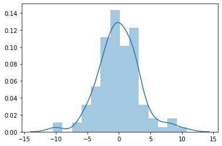

```python
# plot a distribution plot using distplot()
sns.distplot(MLR_model_full.resid)

# display the plot
plt.show()
```

The distribution plot shows a near normal distribution. So, we assume the normality.

|  | **11. Consider the full model build in the previous question. Can we say that the residuals have equal variance?** |
| --- | --- |

Use Breusch-Pagan test for detecting homoskedasticity (equal variance) in the residuals.  
The test hypothesis for the Breusch-Pagan test is given as:

**H<sub>o</sub>: There is homoskedasticity present in the data**

**H<sub>1</sub>: There is a heteroskedasticity present in the data**

```python
# perform Breusch-Pagan test using residuals and independent variables
# compute residuals using 'resid'
# 'exog' returns the independent variables in the model along with the intercept
test = sms.het_breuschpagan(MLR_model_full.resid, MLR_model_full.model.exog)

# the test retuns 4 outputs, the last value is the p-value of the f-statistic
# print the p-value
print('p-value:', test[3])

# print the decision
if test[3] < 0.05:
    print('Heteroskedasticity is present in the data.')
else:
    print('Homoskedasticity is present in the data.')
```

```
p-value: 0.11374698255206975
Homoskedasticity is present in the data.
```

|  | **12. Construct a full no-intecept model. What would you conclude when all the variables take value 0?** |
| --- | --- |

```python
# we include all the numeric predictors
X = df_lifeExp.iloc[:,1:16]

# use 'drop_first' to create (n-1) dummy variables using get_dummies()
# use 'prefix' to add prefix to category of dummy variable
encoded_status = pd.get_dummies(data = df_lifeExp['Status'], drop_first=True, prefix = 'Status')

# concat the dummy variable with features describing immunization
# create a dataframe of all relevant independent variables
# 'axis=1' concates the dataframes along columns
X = pd.concat([pd.DataFrame(X), encoded_status], axis=1)

# set the dependent variable
y = df_lifeExp['Expected']

# building a model with an intercept
# fit() is used to fit the OLS model
MLR_model_full_no_intercept = sm.OLS(y,X).fit()

# print the model sumary
print(MLR_model_full_no_intercept.summary())
```

```
                                 OLS Regression Results
=======================================================================================
Dep. Variable:               Expected   R-squared (uncentered):                   0.993
Model:                            OLS   Adj. R-squared (uncentered):              0.992
Method:                 Least Squares   F-statistic:                              940.0
Date:                Fri, 08 Jan 2021   Prob (F-statistic):                   4.84e-108
Time:                        18:56:41   Log-Likelihood:                         -399.28
No. Observations:                 124   AIC:                                      830.6
Df Residuals:                     108   BIC:                                      875.7
Df Model:                          16
Covariance Type:            nonrobust
======================================================================================
                         coef    std err          t      P>|t|      [0.025      0.975]
--------------------------------------------------------------------------------------
Adult_Mortality       -0.0069      0.007     -0.960      0.339      -0.021       0.007
Infant_Deaths         -0.0807      0.066     -1.224      0.223      -0.211       0.050
Hepatitis              0.0305      0.058      0.523      0.602      -0.085       0.146
Measles               -0.0002      0.000     -1.516      0.133      -0.000    5.18e-05
 BMI                  -0.0697      0.041     -1.696      0.093      -0.151       0.012
Underfive_Deaths       0.0712      0.048      1.482      0.141      -0.024       0.166
Polio                  0.0180      0.040      0.449      0.654      -0.061       0.097
Diphtheria             0.0388      0.073      0.535      0.593      -0.105       0.183
 HIV                   0.5728      0.455      1.258      0.211      -0.330       1.475
GDP                -3.684e-05    6.3e-05     -0.585      0.560      -0.000    8.81e-05
Population         -1.747e-08   1.58e-08     -1.107      0.271   -4.87e-08    1.38e-08
Malnourished10_19     -1.1120      0.546     -2.035      0.044      -2.195      -0.029
Malnourished5_9        1.6540      0.496      3.334      0.001       0.671       2.637
Income_Index          43.2384     11.241      3.846      0.000      20.956      65.520
Schooling              2.1667      0.601      3.608      0.000       0.976       3.357
Status_Developing      7.8535      1.821      4.313      0.000       4.244      11.463
==============================================================================
Omnibus:                        7.813   Durbin-Watson:                   1.591
Prob(Omnibus):                  0.020   Jarque-Bera (JB):                7.565
Skew:                           0.588   Prob(JB):                       0.0228
Kurtosis:                       3.282   Cond. No.                     8.75e+08
==============================================================================

Warnings:
[1] Standard Errors assume that the covariance matrix of the errors is correctly specified.
[2] The condition number is large, 8.75e+08. This might indicate that there are
strong multicollinearity or other numerical problems.
```

If we don't add a constant intercept i.e. the column containing all ones, then the OLS method assumes a column with all zeroes i.e. no intercept. As seen from the above model with no intercept, we got very high values of R-Squared (0.993) and adj. R-Squared (0.992).

Also, the equation of linear regression that we get will have no intercept(constant term). This means that our regression line will pass through the origin. This means that if the value of all the variables is zero, the life expectancy is 0 and that is not possible. There should be some value of life expectancy.

Lets check what will be the impact on the residuals for this no intercept model.

```python
# calculating the sum of the residuals
round(MLR_model_full_no_intercept.resid.sum(), 4)
```

```
53.449
```

The sum of all the residuals must be zero or atleast close to zero for an intercept model. But as we can see from the above calculated sum of residuals, the sum is 53.449. Thus, this model will not perform better.

### Now we shall consider the FEV dataset.

### About the data set (Respiratory function data)

Dataset consists of information about respiratory function in youths and factors that might impact the respiratory function.  
Attribute information:

**Age:** Age in years

**Height (cm):** Height (cm) in cm

**Sex:** Gender of a person

**Smoke_habits** Whether the person is a smoker or non- smoker

**FEV:** Forced Exhalation Volume (FEV), a measure of how much air somebody can forcibly exhale from their lung (Percentage)

#### Load the dataset and check the first five observations

```python
# load the csv file
df_FEV = pd.read_csv('FEV_data.csv')

# display the first two observations
df_FEV.head(2)
```

|  | Age | Height (cm) | Sex | Smoke_habit | FEV |
| --- | --- | --- | --- | --- | --- |
| 0 | 16 | 157.000000 | F | smoker | 1.708000 |
| 1 | 17 | 167.500000 | F | smoker | 1.724000 |

|  | **13. Identify the numeric variable(s) that have highest impact on the FEV of a person** |
| --- | --- |

To Identify the numeric variable(s) that have highest impact on the FEV, we plot the correlation plot displaying the correlation between the idependent numeric and target variable.

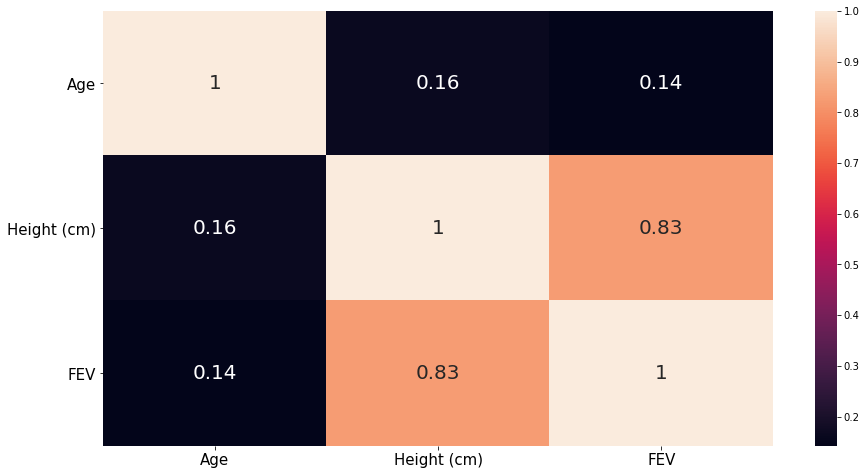

```python
# set dimensions for the plot figure
fig_dims = (15,8)
fig, ax = plt.subplots(figsize=fig_dims)

# create a copy of dataframe
df_FEV_num = df_FEV[["Age","Height (cm)", "FEV"]]

# plot the heat map
# corr: give the correlation matrix
# annot: prints the correlation values in the chart
# annot_kws: sets the font size of the annotation
sns.heatmap(df_FEV_num.corr(), annot = True, annot_kws = {"size": 20})

# rotate the y-axis labels
# set text size using 'fontsize'
plt.yticks(rotation = 'horizontal', fontsize = 15)
plt.xticks(fontsize = 15)

# display the plot
plt.show()
```

The correlation plot shows that, the variables 'Height (cm)' and 'FEV' have a high positive correlation value (0.83).

|  | **14. What is the impact of smoking habit of a person on FEV?** |
| --- | --- |

```python
# consider the independent variables
X = df_FEV["Smoke_habit"]

# convert the categorical variable to dummy variable
# get_dummies(): converts the variable to categorical variable
# drop_first=True: indicates n-1 dummy enoding; if set to false indicated one-hot encoding
X = pd.get_dummies(X, drop_first=True)

# consider the dependent variable
y = df_FEV["FEV"]

# fit a model with an intercept using fit()
# add_constant(): adds the intercept term to the model
LM_model = sm.OLS(y, sm.add_constant(X)).fit()

# print the summary output
print(LM_model.summary())
```

```
                            OLS Regression Results
==============================================================================
Dep. Variable:                    FEV   R-squared:                       0.098
Model:                            OLS   Adj. R-squared:                  0.097
Method:                 Least Squares   F-statistic:                     70.92
Date:                Fri, 08 Jan 2021   Prob (F-statistic):           2.36e-16
Time:                        18:56:41   Log-Likelihood:                -800.43
No. Observations:                 654   AIC:                             1605.
Df Residuals:                     652   BIC:                             1614.
Df Model:                           1
Covariance Type:            nonrobust
==============================================================================
                 coef    std err          t      P>|t|      [0.025      0.975]
------------------------------------------------------------------------------
const          3.4206      0.098     34.729      0.000       3.227       3.614
smoker        -0.8778      0.104     -8.422      0.000      -1.082      -0.673
==============================================================================
Omnibus:                       37.782   Durbin-Watson:                   1.125
Prob(Omnibus):                  0.000   Jarque-Bera (JB):               42.957
Skew:                           0.622   Prob(JB):                     4.70e-10
Kurtosis:                       3.167   Cond. No.                         5.96
==============================================================================

Warnings:
[1] Standard Errors assume that the covariance matrix of the errors is correctly specified.
```

Considering only the smoking habit, we see that the variable contributes to 9.8% of variation in FEV. The parameter 'const' represents the level 'non-smoker'.

|  | **15. A Linear regression model is used to analyze the impact of all possible features on respiratory function (FEV). How do we check whether there is multicollinearity present or not?** |
| --- | --- |

```python
# consider the independent variables
# select_dtypes: selects the desired the variable having specified datatype
# include: includes the variables with specified datatype
# drop(): drops specified column(s)/row(s) from the dataframe
# axis: specifies whether to drop labels from index or columns; use 1 for columns and 0 for index
df_FEV_num = df_FEV.select_dtypes(include=np.number).drop(["FEV"],axis=1)

# consider all the categorical variables in the data
# select_dtypes: selects the desired the variable having specified datatype
# include: includes the variables with specified datatype
df_FEV_cat = df_FEV.select_dtypes(include="object")

# convert the categorical variable to dummy variable
# get_dummies(): converts the variable to categorical variable
# drop_first=True: indicates n-1 dummy enoding; if set to false indicated one-hot encoding
dummy_variables = pd.get_dummies(df_FEV_cat, drop_first=True)

# concatenate the numerical and dummy variables
# axis: specifies whether to drop labels from index or columns; use 1 for columns and 0 for index
X = pd.concat([df_FEV_num, dummy_variables],axis=1)

# consider the dependent variable
y = df_FEV["FEV"]

# fit a full model with an intercept using fit()
# add_constant(): adds the intercept term to the model
MLR_model = sm.OLS(y, sm.add_constant(X)).fit()

# print the summary output
print(MLR_model.summary())
```

```
                            OLS Regression Results
==============================================================================
Dep. Variable:                    FEV   R-squared:                       0.701
Model:                            OLS   Adj. R-squared:                  0.699
Method:                 Least Squares   F-statistic:                     379.5
Date:                Fri, 08 Jan 2021   Prob (F-statistic):          2.78e-168
Time:                        18:56:41   Log-Likelihood:                -439.94
No. Observations:                 654   AIC:                             889.9
Df Residuals:                     649   BIC:                             912.3
Df Model:                           4
Covariance Type:            nonrobust
======================================================================================
                         coef    std err          t      P>|t|      [0.025      0.975]
--------------------------------------------------------------------------------------
const                -16.5268      0.575    -28.727      0.000     -17.656     -15.397
Age                    0.0026      0.007      0.374      0.708      -0.011       0.016
Height (cm)            0.1192      0.003     34.063      0.000       0.112       0.126
Sex_M                  0.1801      0.038      4.769      0.000       0.106       0.254
Smoke_habit_smoker    -0.2231      0.063     -3.515      0.000      -0.348      -0.098
==============================================================================
Omnibus:                      113.397   Durbin-Watson:                   1.647
Prob(Omnibus):                  0.000   Jarque-Bera (JB):              652.393
Skew:                          -0.625   Prob(JB):                    2.16e-142
Kurtosis:                       7.730   Cond. No.                     5.03e+03
==============================================================================

Warnings:
[1] Standard Errors assume that the covariance matrix of the errors is correctly specified.
[2] The condition number is large, 5.03e+03. This might indicate that there are
strong multicollinearity or other numerical problems.
```

As the condition number is very high (5.03e+03) we can see that the multicollinearity is present in the data.

|  | **16. A Linear regression model is used to analyze the impact of all possible features on respiratory function (FEV). Check whether the error terms are serially independent?** |
| --- | --- |

To check the assumption of autocorrelation we shall conduct the Durbin-Watson test. The hypothesis for the test are:

**H<sub>o</sub>: The error terms are not autocorrelated**

**H<sub>1</sub>: TThe error terms are autocorrelated**

```python
# consider the independent variables
# select_dtypes: selects the desired the variable having specified datatype
# include: includes the variables with specified datatype
# drop(): drops specified column(s)/row(s) from the dataframe
# axis: specifies whether to drop labels from index or columns; use 1 for columns and 0 for index
df_FEV_num = df_FEV.select_dtypes(include=np.number).drop(["FEV"],axis=1)

# consider all the categorical variables in the data
# select_dtypes: selects the desired the variable having specified datatype
# include: includes the variables with specified datatype
df_FEV_cat = df_FEV.select_dtypes(include="object")

# convert the categorical variable to dummy variable
# get_dummies(): converts the variable to categorical variable
# drop_first=True: indicates n-1 dummy enoding; if set to false indicated one-hot encoding
dummy_variables = pd.get_dummies(df_FEV_cat, drop_first=True)

# concatenate the numerical and dummy variables
# axis: specifies whether to drop labels from index or columns; use 1 for columns and 0 for index
X = pd.concat([df_FEV_num, dummy_variables],axis=1)

# consider the dependent variable
y = df_FEV["FEV"]

# fit a full model with an intercept using fit()
# add_constant(): adds the intercept term to the model
MLR_model = sm.OLS(y, sm.add_constant(X)).fit()

# compute residuals using 'resid'
residuals = MLR_model.resid

# perform Durbin-Watson test
durbin_watson(residuals)
```

```
1.6472983005218602
```

From the test statistic, we conclude that there is a slight positive serial correlation.

|  | **17. A model is built using all the features to predict the FEV. Check whether the residuals obtained form the model are normally distributed.** |
| --- | --- |

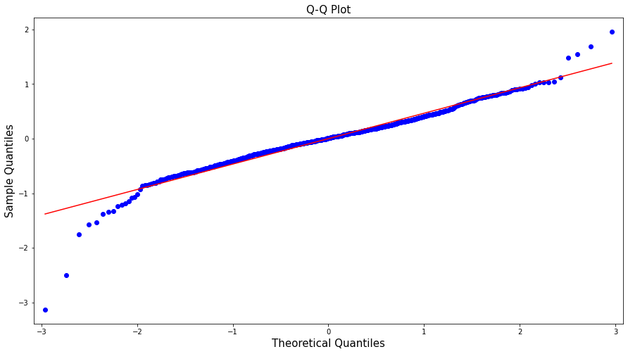

```python
# consider the independent variables
# select_dtypes: selects the desired the variable having specified datatype
# include: includes the variables with specified datatype
# drop(): drops specified column(s)/row(s) from the dataframe
# axis: specifies whether to drop labels from index or columns; use 1 for columns and 0 for index
df_FEV_num = df_FEV.select_dtypes(include=np.number).drop(["FEV"],axis=1)

# consider all the categorical variables in the data
# select_dtypes: selects the desired the variable having specified datatype
# include: includes the variables with specified datatype
df_FEV_cat = df_FEV.select_dtypes(include="object")

# convert the categorical variable to dummy variable
# get_dummies(): converts the variable to categorical variable
# drop_first=True: indicates n-1 dummy enoding; if set to false indicated one-hot encoding
dummy_variables = pd.get_dummies(df_FEV_cat, drop_first=True)

# concatenate the numerical and dummy variables
# axis: specifies whether to drop labels from index or columns; use 1 for columns and 0 for index
X = pd.concat([df_FEV_num, dummy_variables],axis=1)

# consider the dependent variable
y = df_FEV["FEV"]

# fit a full model with an intercept using fit()
# add_constant(): adds the intercept term to the model
MLR_model = sm.OLS(y, sm.add_constant(X)).fit()

# set the plot size
plt.rcParams['figure.figsize'] = (15,8)

# plot the Q-Q plot
# 'r' represents the regression line
qqplot(MLR_model.resid, line = 'r')

# set plot and axes labels
# set text size using 'fontsize'
plt.title('Q-Q Plot', fontsize = 15)
plt.xlabel('Theoretical Quantiles', fontsize = 15)
plt.ylabel('Sample Quantiles', fontsize = 15)

# display the plot
plt.show()
```

The diagonal line (red line) is the regression line and the blue points are the cumulative distribution of the residuals. As, most of the points are close to the diagonal line, we conclude that the residuals follow a near normal distribution.

## 6. Model Performance

|  | **18. Build a full model on 70% of the given data. Calculate the mean square error and the root mean square error on the test set.** |
| --- | --- |

```python
# consider the independent variables
# select_dtypes: selects the desired the variable having specified datatype
# include: includes the variables with specified datatype
# drop(): drops specified column(s)/row(s) from the dataframe
# axis: specifies whether to drop labels from index or columns; use 1 for columns and 0 for index
df_FEV_num = df_FEV.select_dtypes(include=np.number).drop(["FEV"],axis=1)

# consider all the categorical variables in the data
# select_dtypes: selects the desired the variable having specified datatype
# include: includes the variables with specified datatype
df_FEV_cat = df_FEV.select_dtypes(include="object")

# convert the categorical variable to dummy variable
# get_dummies(): converts the variable to categorical variable
# drop_first=True: indicates n-1 dummy enoding; if set to false indicated one-hot encoding
dummy_variables = pd.get_dummies(df_FEV_cat, drop_first=True)

# concatenate the numerical and dummy variables
# axis: specifies whether to drop labels from index or columns; use 1 for columns and 0 for index
X = pd.concat([df_FEV_num, dummy_variables],axis=1)

# add_constant(): adds the intercept term to the model
X = sm.add_constant(X)

# consider the dependent variable
y = df_FEV["FEV"]

# split data into train subset and test subset
# set 'random_state' to generate the same dataset each time you run the code
# 'test_size' returns the proportion of data to be included in the testing set
X_train, X_test, y_train, y_test = train_test_split(X, y, random_state = 1, test_size = 0.3)

# fit a full model using fit()
MLR_model = sm.OLS(y, X).fit()
```

```python
# predict the y values
y_pred = MLR_model.predict(X_test)

# calculating the MSE for the test data and then rounding the value upto 4 digits
mse_test = round(mean_squared_error(y_test, y_pred),4)

# printing the mse for the test set
print("Mean Squared Error (MSE): ", mse_test)

# taking the square root of the mse and then rounding the value upto 4 digits
rmse_test = round(np.sqrt(mse_test), 4)

# printing the rmse for the test set
print("Root Mean Squared Error (RMSE): ", rmse_test)
```

```
Mean Squared Error (MSE):  0.2403
Root Mean Squared Error (RMSE):  0.4902
```

|  | **19. Calculate the mean absolute error and the mean absolute percentage error for the test set using the model in Q18. Compare the values of RMSE and MAE.** |
| --- | --- |

```python
# a user defined function to calculate MAPE
# the function take arguments: actual and predicted values
# it returns the MAPE
def mape(actual, predicted):
    return (np.mean(np.abs((actual - predicted) / actual)) * 100)
```

```python
# consider the full model in Q18
# calculating the MAE for the test data and then rounding the value upto 4 digits
mae_test = round(mean_absolute_error(y_test, y_pred),4)

# printing the MAE for the test set
print("Mean Absolute Error (MAE) on test set: ", mae_test)

# Calculating the MAPE using the "mape()" function created above

# calculating the MAPE for the  data and then rounding the value upto 4 digits
mape_test = round(mape(y_test, y_pred),4)

# printing the mape for the tra set
print("Mean Absolute Percentage Error (MAPE) on test set: ", mape_test)
```

```
Mean Absolute Error (MAE) on test set:  0.3572
Mean Absolute Percentage Error (MAPE) on test set:  14.4264
```

As you can see, the value of RMSE is greater than the value of MAE. The reason for this is that the RMSE punishes the model for large error terms. Thus, RMSE is a robust method that is generally used.

|  | **20. Build the full model on 80% of the given data and check if the model is overfitted?** |
| --- | --- |

```python
# consider the independent variables
# select_dtypes: selects the desired the variable having specified datatype
# include: includes the variables with specified datatype
# drop(): drops specified column(s)/row(s) from the dataframe
# axis: specifies whether to drop labels from index or columns; use 1 for columns and 0 for index
df_FEV_num = df_FEV.select_dtypes(include=np.number).drop(["FEV"],axis=1)

# consider all the categorical variables in the data
# select_dtypes: selects the desired the variable having specified datatype
# include: includes the variables with specified datatype
df_FEV_cat = df_FEV.select_dtypes(include="object")

# convert the categorical variable to dummy variable
# get_dummies(): converts the variable to categorical variable
# drop_first=True: indicates n-1 dummy enoding; if set to false indicated one-hot encoding
dummy_variables = pd.get_dummies(df_FEV_cat, drop_first=True)

# concatenate the numerical and dummy variables
# axis: specifies whether to drop labels from index or columns; use 1 for columns and 0 for index
X = pd.concat([df_FEV_num, dummy_variables],axis=1)

# add_constant(): adds the intercept term to the model
X = sm.add_constant(X)

# consider the dependent variable
y = df_FEV["FEV"]

# split data into train subset and test subset
# set 'random_state' to generate the same dataset each time you run the code
# 'test_size' returns the proportion of data to be included in the testing set
X_train, X_test, y_train, y_test = train_test_split(X, y, random_state = 1, test_size = 0.2)

# fit a full model using fit()
MLR_model = sm.OLS(y, X).fit()

# print the model summary
print(MLR_model.summary())

# For training set:
# train_pred: Prediction made by the model on the training dataset 'X_train'
# y_train: Actual values of the target variable for the train dataset

# For testing set:
# test_pred: Prediction made by the model on the test dataset 'y_train'
# y_test: Actual values of the target variable for the test dataset

# Predicting the output of the target variable from the train data
train_pred = MLR_model.predict(X_train)

# Predicting the output of the target variable from the test data
test_pred = MLR_model.predict(X_test)

# Calculating the mse using the "mean_squared_error" function

# MSE for the train data
mse_train = mean_squared_error(y_train, train_pred)

# taking the square root of the mse and then rounding the value upto 4 digits
rmse_train = round(np.sqrt(mse_train), 4)

# printing the rmse for the train set
print("\n Root Mean Squared Error (RMSE) on train set: ", rmse_train)

# MSE for the test data
mse_test = mean_squared_error(y_test, test_pred)

# taking the square root of the mse and then rounding the value upto 4 digits
rmse_test = round(np.sqrt(mse_test), 4)

# printing the rmse for the test set
print("\n Root Mean Squared Error (RMSE) on test set: ", rmse_test)
```

```
                            OLS Regression Results
==============================================================================
Dep. Variable:                    FEV   R-squared:                       0.701
Model:                            OLS   Adj. R-squared:                  0.699
Method:                 Least Squares   F-statistic:                     379.5
Date:                Fri, 08 Jan 2021   Prob (F-statistic):          2.78e-168
Time:                        18:56:42   Log-Likelihood:                -439.94
No. Observations:                 654   AIC:                             889.9
Df Residuals:                     649   BIC:                             912.3
Df Model:                           4
Covariance Type:            nonrobust
======================================================================================
                         coef    std err          t      P>|t|      [0.025      0.975]
--------------------------------------------------------------------------------------
const                -16.5268      0.575    -28.727      0.000     -17.656     -15.397
Age                    0.0026      0.007      0.374      0.708      -0.011       0.016
Height (cm)            0.1192      0.003     34.063      0.000       0.112       0.126
Sex_M                  0.1801      0.038      4.769      0.000       0.106       0.254
Smoke_habit_smoker    -0.2231      0.063     -3.515      0.000      -0.348      -0.098
==============================================================================
Omnibus:                      113.397   Durbin-Watson:                   1.647
Prob(Omnibus):                  0.000   Jarque-Bera (JB):              652.393
Skew:                          -0.625   Prob(JB):                    2.16e-142
Kurtosis:                       7.730   Cond. No.                     5.03e+03
==============================================================================

Warnings:
[1] Standard Errors assume that the covariance matrix of the errors is correctly specified.
[2] The condition number is large, 5.03e+03. This might indicate that there are
strong multicollinearity or other numerical problems.

 Root Mean Squared Error (RMSE) on train set:  0.4694

 Root Mean Squared Error (RMSE) on test set:  0.4928
```

The difference between the RMSE values of the train and the test set is very less. Thus, it can be said that the model is not overfitted. If a significant difference is seen in the RMSE of the train and the test set, then it can be said that the model is overfitted on the train set.